# Part 1: Pre-Preparation

### 1.1 Business Questions

- (A) Increase customer happiness/satisfaction
  - How can we reduce customer waiting time
  - How does one measure satisfaction? vs lack of engagement?
- (B) Improve Chime employee customer efficiency and ability to support customer
- (C) Can we derive more usage from the data?
  - Can we get map intent to interests?
  - Can we get map intent to product stickiness?

### 1.2 How to Structure ML Problems ?

- Assuming we are solving the problem of predicting intent given a text
  - Supervised model (vs clustering vs semi-supervised)
  - Classification problem (vs regression)
  - Either
    - Both model learns conditional probabibilty P(intent|text)
    - Generative Classifiers (Bayesian )
      - learns the joint probability P(x,y); distance between samples
      - Then use Bayesian to get conditonal probability
      - Examples: Naive Bayes, Markov Random Fields
    - Discriminative Classifier ( P(intent | text) ) by learning decision boundaries and model/statistic parameters
      - Examples: Logistic regression, SVM, NN, Nearest Network

### 1.3 Identify what Analysis you want to conduct, and the modeling approaches

- For analysis, please see analysis below

### 1.4 Given Schema of dataset, how you improve model performance?

- More data for low performing categories
- To solve business question A, introduce time element spent

# Part 2: Data Preparation

### 2.1 Import Data

```python
import os
import pandas as pd
import matplotlib.pyplot as plt
import nltk

df_message_intent: pd.core.frame.DataFrame = pd.read_csv(f'{os.getcwd()}/data/message_intent.csv')

# Drop any rows with NA
df_message_intent.dropna()

# There are duplicate texts since text.count < text.unique
df_message_intent.describe()
```

|  | text | intent |
| --- | --- | --- |
| count | 707 | 707 |
| unique | 665 | 5 |
| top | can i transfer funds without a debit card | move_money |
| freq | 2 | 239 |

```python
df_message_intent.head(5)
```

|  | text | intent |
| --- | --- | --- |
| 0 | chime checkbook limits | move_money |
| 1 | can i have a savings account? | account_and_cards |
| 2 | can i have my tax money? | miscellaneous |
| 3 | how to send money using my chime account | move_money |
| 4 | how to set my pin for atm | account_and_cards |

### 2.2 Mock Data

- Users
- Transactions
- App_events

```python
users = [ ['Tom',   '1977-04-01', 'Y', 0.5, 11],
          ['Mason', '2011-09-02', 'Y', 0.8, 5]
        ]
users_df = pd.DataFrame(users, columns = ['id', 'enrollment_date', 'has_savings_account', 'kyc_score', 'disputes_count'])

transactions = [['Tom', 'deposit', 111.11, 1001],
                ['Tom', 'debit',   5.00,   1002],
                ['Tom', 'debit',   15.00,  1003],
                ['Tom', 'deposit', 33.33,  1004],
                ['Mason', 'deposit', 222.22,  1001],
                ['Mason', 'debit', 4.00,  1002],
                ['Mason', 'debit', 7.00,  1003],
               ]
transactions_df = pd.DataFrame(transactions , columns = ['id', 'type', 'amount', 'trans_ts'])

appevents = [
    ['Tom', 'home', 1001],
    ['Tom', 'home', 1002],
    ['Mason', 'sigin', 1002]
]
appevents_df = pd.DataFrame(appevents , columns = ['id', 'screen', 'timestamp'])
```

```python
import sqlite3
conn = sqlite3.connect('TestDB1.db')
c: sqlite3.Cursor = conn.cursor()

c.execute('DROP TABLE USERS')
c.execute('CREATE TABLE USERS (id, enrollment_date, has_savings_account, kyc_score, disputes_count)')

c.execute('DROP TABLE TRANSACTIONS')
c.execute('CREATE TABLE TRANSACTIONS (id, type, amount, trans_ts)')

c.execute('DROP TABLE APPEVENTS')
c.execute('CREATE TABLE APPEVENTS (id, screen, timestamp)')

conn.commit()

users_df.to_sql('USERS', conn, if_exists='replace', index=False)
transactions_df.to_sql('TRANSACTIONS', conn, if_exists='replace', index=False)
appevents_df.to_sql('APPEVENTS', conn, if_exists='replace', index=False)
```

```python
def execute_sql(sql: str):
    c.execute(sql)
    for row in c.fetchall():
        print(row)
```

#### JOINS

```python
execute_sql(
    """
    select *
    from USERS as u
    INNER JOIN TRANSACTIONS as t ON u.id=t.id
    WHERE
        (t.trans_ts BETWEEN 1000 AND 2000)
        AND (u.enrollment_date BETWEEN '1977-03-01' AND '2011-09-03')
    ORDER BY t.id, t.trans_ts ASC
    """
)
```

```
('Mason', '2011-09-02', 'Y', 0.8, 5, 'Mason', 'deposit', 222.22, 1001)
('Mason', '2011-09-02', 'Y', 0.8, 5, 'Mason', 'debit', 4.0, 1002)
('Mason', '2011-09-02', 'Y', 0.8, 5, 'Mason', 'debit', 7.0, 1003)
('Tom', '1977-04-01', 'Y', 0.5, 11, 'Tom', 'deposit', 111.11, 1001)
('Tom', '1977-04-01', 'Y', 0.5, 11, 'Tom', 'debit', 5.0, 1002)
('Tom', '1977-04-01', 'Y', 0.5, 11, 'Tom', 'debit', 15.0, 1003)
('Tom', '1977-04-01', 'Y', 0.5, 11, 'Tom', 'deposit', 33.33, 1004)
```

#### Query against the result of Another Query

```python
execute_sql(
    """
    select COUNT(*), SUM(SUBQUERY.amount) from (
        select *
        from USERS as u
        INNER JOIN TRANSACTIONS as t ON u.id=t.id
        ORDER BY t.id, t.trans_ts ASC
    ) as SUBQUERY
    """
)
```

```
(7, 397.65999999999997)
```

#### Window

```python
execute_sql(
    """
    select
        id,
        type,
        SUM(amount) OVER
        (PARTITION BY id, type, amount ORDER BY trans_ts) as x
    FROM TRANSACTIONS
    """
)
```

[output not shown]

### 2.3 Data Analysis

```python
classes = df_message_intent['intent'].unique()
num_classes = len(df_message_intent['intent'].unique())
print(f'There are {num_classes} classes: {classes}')
```

```
There are 5 classes: ['move_money' 'account_and_cards' 'miscellaneous' 'spend_money' 'support']
```

#### Class Histogram

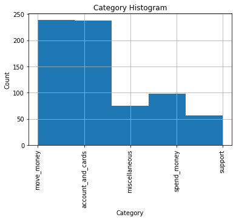

```python
df_message_intent['intent'].hist(bins=num_classes)
plt.title('Category Histogram')
plt.ylabel('Count')
plt.xlabel('Category')
plt.xticks(rotation='vertical')
plt.show()
```

```python
df_message_intent['intent'].value_counts()
```

```
move_money           239
account_and_cards    238
spend_money           98
miscellaneous         75
support               57
Name: intent, dtype: int64
```

#### Average Text Length

```python
df_message_intent['avg_length'] = df_message_intent['text'].apply(lambda row: len(str(row)))
df_message_intent['avg_length'].describe()
```

```
count    707.000000
mean      29.182461
std       10.286509
min        4.000000
25%       21.000000
50%       29.000000
75%       37.000000
max       48.000000
Name: avg_length, dtype: float64
```

### 2.4 Data Wrangling

#### Preprocess Data

```python
# Reference: https://towardsdatascience.com/text-normalization-with-spacy-and-nltk-1302ff430119
# Flow
# tokenization -> lemmatization --> remove stop words --> remove punctuations

# Type of normalization
# lemmatization: reduce word-froms to linguistically valid meanings
# Stemming: reduce words to potentially meaningless

# Stop words: set of commonly words, like a, the, is

import spacy
# python3 -m spacy download en_core_web_sm

nlp = spacy.load("en_core_web_sm", disable = ['ner', 'tagger', 'parser', 'textcat'])
def preprocess(text:str):
    text_tokens = nlp(text)
    return ' '.join(token.text for token in text_tokens)\
        .lower()\
        .replace('\n', ' ')

df_message_intent['text_normalized'] = df_message_intent['text'].apply(lambda row: preprocess(row))

df_message_intent.head(5)
```

[output not shown]

[output cut: 1288 more lines]

|  | text | intent | text_normalized |
| --- | --- | --- | --- |
| 0 | chime checkbook limits | move_money | chime checkbook limits |
| 1 | can i have a savings account? | account_and_cards | can i have a savings account ? |
| 2 | can i have my tax money? | miscellaneous | can i have my tax money ? |
| 3 | how to send money using my chime account | move_money | how to send money using my chime account |
| 4 | how to set my pin for atm | account_and_cards | how to set my pin for atm |

```python
df_message_intent['text_normalized'].head(5)
```

```
0                      chime checkbook limits
1              can i have a savings account ?
2                   can i have my tax money ?
3    how to send money using my chime account
4                   how to set my pin for atm
Name: text_normalized, dtype: object
```

#### Drop duplicates

```python
df_message_intent = df_message_intent.drop_duplicates(subset=['text', 'intent']).reset_index(drop=True)
df_message_intent.describe()
```

|  | text | intent | text_normalized |
| --- | --- | --- | --- |
| count | 665 | 665 | 665 |
| unique | 665 | 5 | 665 |
| top | chime checkbook limits | account_and_cards | chime checkbook limits |
| freq | 1 | 225 | 1 |

#### Map Labels

```python
classes
```

```
array(['move_money', 'account_and_cards', 'miscellaneous', 'spend_money',
       'support'], dtype=object)
```

```python
label_mapping = {
    'move_money' : '__label__movemoney',
    'account_and_cards' : '__label__acccountandcards',
    'miscellaneous' : '__label__miscellaneous',
    'spend_money' : '__label__spend_money',
    'support': '__label__support'
}

#df_message_intent['label'] = df_message_intent['intent'].apply(lambda intent: label_mapping[intent] if intent in label_mapping else -1)
#df_message_intent = df_message_intent[ df_message_intent['label'] != -1 ]

df_message_intent['label'] = df_message_intent['intent'].str.lower().map(label_mapping)
df_message_intent = df_message_intent[ ['label', 'text_normalized']]
df_message_intent.head(2)
```

|  | label | text_normalized |
| --- | --- | --- |
| 0 | __label__movemoney | chime checkbook limits |
| 1 | __label__acccountandcards | can i have a savings account ? |

#### Split the data

```python
user | msgCnt | time
A                 1    Training
A                 2    Training
A                 3    Gap
A                 4    Test
A                 5    Validation
```

```python
# for training and test
num_head = int(df_message_intent.shape[0] * 0.9)
df_train_test = df_message_intent.head(num_head)
from sklearn.model_selection import train_test_split
df_train, df_test = train_test_split(df_train_test, test_size=0.1, random_state=1, stratify=df_train_test['label'])
df_train.to_csv(f'{os.getcwd()}/train.csv', sep='\t', header=None, index=None)
df_test.to_csv(f'{os.getcwd()}/test.csv', sep='\t', header=None, index=None)


# for validation
num_tail = df_message_intent.shape[0] - head
df_valid = df_message_intent.tail(num_tail)
df_valid.to_csv(f'{os.getcwd()}/valid.csv', sep='\t', header=None, index=None)


print(f'#train={df_train.shape[0]} #test={df_test.shape[0]} #valid={df_valid.shape[0]}')
```

[output not shown]

# Part 3: Train & Evaluation

### 3.1 Train Model

```python
df_train.head(2)
```

|  | label | text_normalized |
| --- | --- | --- |
| 205 | __label__movemoney | how do i wire funds |
| 353 | __label__support | how do i get a live operator |

```python
import fasttext

model = fasttext.train_supervised(f'{os.getcwd()}/train.csv', epoch=80,  lr=0.8)

print(f'Model.labels={model.labels}     VocabSize={len(model.words)}')
```

```
Model.labels=['__label__acccountandcards', '__label__movemoney', '__label__spend_money', '__label__miscellaneous', '__label__support']     VocabSize=596
```

```
Read 0M words
Number of words:  596
Number of labels: 5
Progress: 100.0% words/sec/thread:  482244 lr:  0.000000 avg.loss:  0.150600 ETA:   0h 0m 0s
```

```python
model.predict("Which baking dish is best to bake a banana bread ?")
```

```
(('__label__miscellaneous',), array([0.4200305]))
```

### 3.2 Evaluation

```python
from sklearn.metrics import matthews_corrcoef, accuracy_score
from sklearn.metrics import f1_score, precision_score, recall_score
from sklearn.metrics import roc_auc_score, roc_curve
from sklearn.metrics import auc, precision_recall_curve
import matplotlib.pyplot as plt

from sklearn import metrics
```

```python
testDF = pd.read_csv(f'{os.getcwd()}/test.csv', sep='\t', header=None)
testDF.head(2)
```

|  | 0 | 1 |
| --- | --- | --- |
| 0 | __label__movemoney | how long does it take paypal to transfer money |
| 1 | __label__spend_money | mark a transaction as safe |

```python
import itertools
pred_test = model.predict(testDF.iloc[:,1].to_list())[0] # pass into python list of all the second columns, ie title?
pred_test = list(itertools.chain(*pred_test))

true_test = testDF.iloc[:, 0].to_list() #aka label
assert len(true_test) == len(pred_test)
```

#### Precision Recall

```python
model.test(f'{os.getcwd()}/test.csv', k=1)
# precision, recall
```

```
(60, 0.6833333333333333, 0.6833333333333333)
```

```python
print(metrics.confusion_matrix(true_test, pred_test))

print(metrics.classification_report(true_test, pred_test, digits=3))
```

```
[[15  0  2  3  0]
 [ 0  3  2  1  0]
 [ 3  0 15  2  0]
 [ 0  2  1  6  0]
 [ 1  0  1  1  2]]
                           precision    recall  f1-score   support

__label__acccountandcards      0.789     0.750     0.769        20
   __label__miscellaneous      0.600     0.500     0.545         6
       __label__movemoney      0.714     0.750     0.732        20
     __label__spend_money      0.462     0.667     0.545         9
         __label__support      1.000     0.400     0.571         5

                 accuracy                          0.683        60
                macro avg      0.713     0.613     0.633        60
             weighted avg      0.714     0.683     0.684        60
```

# Appendix

### More low form of normalization with spacy

```python
nlp = spacy.load('en_core_web_sm')
def preprocess(text: str, b_debug: bool=False):
    doc = nlp(text)
    lemma_list = []
    for token in doc:
        lemma_list.append(token.lemma_)
    if b_debug:
        print("Tokenize+Lemmatize:")
        print(lemma_list)

    #Filter the stopword
    filtered_sentence =[]
    for word in lemma_list:
        lexeme = nlp.vocab[word]
        if lexeme.is_stop == False:
            filtered_sentence.append(word)

    #Remove punctuation
    punctuations="?:!.,;"
    for word in filtered_sentence:
        if word in punctuations:
            filtered_sentence.remove(word)
    if b_debug:
        print(" ")
        print("Remove stopword & punctuation: ")
        print(filtered_sentence)

    return filtered_sentence
preprocess('Hi There Tom creating ! create')
```

### Systems

```python
(1)  model1 --> embedings in HDFS
        fnc(userID)  --> embedding
        df['inference'] = model.predict(text)
        HDFS


(2) model2 online service (service team)
    how do you pulls this in?

    Question: HDFS --> feature datastore


(3) http request workflow
    context: user loggined in --> id --> transformation(handle PPI) --> HDFS
        userName: TomChang
        HDFS datastore: userid: 12345

    Potentail problems
        cold start:
            userId just signed up, you don't have an embeddings
            non-Chime user

            generalization: mismatch between your HDFS key and software stack key

            general embedings based on (age, sex, location)
                tom log in --> userDB --> (age, M)
                    --> HDFS
                        user1 --> embedding
                        () --> embedding_default
                        (age, M) --> embedding_default
                        (age, M, CA) --> embedding_default

                training dataste
                    age    sex  location
                    25     M    CA       --> embedding_default

        request : badis
        system intermitten: bad pods, etc...

- Challenges of traing embedding per user
    100 million --> update your embedding

    how often run it?  new users?

Q1: Model pre-prod evaluation

- hold out data validation
    Train model --> (training, test, hold out)


- historical data validation
    potential time range diff
    golden human label dataset

- Load testing (TPS, memory consumption)

- Baseline
    other model in production



f1 vs
  auc vs proc

  precision recall --> class imbalanced dataset
  AUC --> ??
  F1 = fnc(precision, recall)
Q2: Model --> Production
- monitor metrics for model performance

- Metrics
    visbility:
        model
            version
            performance: accuracy, precision --> label?

        data
            data distribtuion

        Systesm: TPS, eroror rates
            Prometheus,

        Logging
            logging agent in your push

    Logging
        - input, prediction, label (ie item clicks)

        - text length: #
            percentile of length --> 5th percentile < 10  --> trigger





- Alerts
    Logging
        prometheus
```